# Assignment 3 - Text Mining

Author

Nate Truettner

## Text Mining

```r
library(readr)
library(dplyr)
library(tidytext)
library(ggplot2)
library(tidyr)
pubmed <- read.csv('pubmed.csv')
```

### Question 1

```r
table(pubmed$term)
```

```
          covid cystic fibrosis      meningitis    preeclampsia prostate cancer
            981             376             317             780             787
```

There are 981 abstracts associated with “covid”, 376 associated with “cystic fibrosis”, 317 associated with “meningitis”, 780 associated with “preeclampsia”, and 787 associated with “prostate cancer”.

```r
tokens <- pubmed %>%
  unnest_tokens(word, abstract)
token_counts <- tokens %>%
  dplyr::count(term, word, sort = TRUE)
top5 <- token_counts %>%
  group_by(term) %>%
  slice_max(n, n = 5)
top5
```

```
# A tibble: 25 × 3
# Groups:   term [5]
   term            word      n
   <chr>           <chr> <int>
 1 covid           the    9741
 2 covid           of     7668
 3 covid           covid  7275
 4 covid           19     7035
 5 covid           and    6861
 6 cystic fibrosis the    2677
 7 cystic fibrosis of     2304
 8 cystic fibrosis and    1777
 9 cystic fibrosis in     1497
10 cystic fibrosis to     1011
# ℹ 15 more rows
```

-The 5 most common tokens for “covid” are (the, of, covid, 19, and)  
-The 5 most common tokens for “cystic fibrosis” are (the, of, and, in, to)  
-The 5 most common tokens for “meningitis” are (the, of, and, in, a)  
-The 5 most common tokens for “preeclampsia” are (the, of, and, in, to)  
-The 5 most common tokens for “prostate cancer” are (the, of, and, cancer, prostate)  
There is not a lot interesting to take away here; these are mostly stop words and do not give any insight into the contents of the abstracts, save for a few obviously related words like “prostate” and “cancer”.

### Question 2

```r
data("stop_words")

tokens_clean <- tokens %>%
  anti_join(stop_words, by = "word")

top5_updated <- tokens_clean %>%
  dplyr::count(term, word, sort = TRUE) %>%
  group_by(term) %>%
  slice_max(n, n = 5)

top5_updated
```

```
# A tibble: 25 × 3
# Groups:   term [5]
   term            word         n
   <chr>           <chr>    <int>
 1 covid           covid     7275
 2 covid           19        7035
 3 covid           patients  2293
 4 covid           disease    943
 5 covid           pandemic   800
 6 cystic fibrosis fibrosis   867
 7 cystic fibrosis cystic     862
 8 cystic fibrosis cf         625
 9 cystic fibrosis patients   586
10 cystic fibrosis disease    400
# ℹ 15 more rows
```

After removing the stop words:  
-The 5 most common tokens for “covid” are (covid, 19, patients, disease, pandemic)  
-The 5 most common tokens for “cystic fibrosis” are (fibrosis, cystic, cf, patients, disease)  
-The 5 most common tokens for “meningitis” are (patients, meningitis, meningeal, csf, clinical)  
-The 5 most common tokens for “preeclampsia” are (pre, eclampsia, preeclampsia, women, pregnancy)  
-The 5 most common tokens for “prostate cancer” are (cancer, prostate, patients, treatment, disease)  
This is a bit more interesting than the previous analysis. I notice that “women” and “pregnancy” are common tokens for the preeclampsia search term; these are some of the few words that would not be totally obvious as top 5 abstract tokens when looking at the search term. “Treatment” is also interesting for the prostate cancer search term, as that would indicate that many studies are focused on treating the disease or involve treatment in some fashion.

### Question 3

```r
bigrams <- pubmed %>%
  unnest_tokens(bigram, abstract, token = "ngrams", n = 2)
bigrams_sep <- bigrams %>%
  separate(bigram, into = c("word1", "word2"), sep = " ")
bigrams_filtered <- bigrams_sep %>%
  dplyr::filter(!word1 %in% stop_words$word,
         !word2 %in% stop_words$word)
bigram_counts <- bigrams_filtered %>%
  unite(bigram, word1, word2, sep = " ") %>%
  dplyr::count(bigram, sort = TRUE)
top10_bigrams <- bigram_counts %>%
  slice_max(n, n = 10)

top10_bigrams
```

```
                bigram    n
1             covid 19 6969
2      prostate cancer 3222
3        pre eclampsia 1854
4      cystic fibrosis  860
5          19 patients  447
6          19 pandemic  419
7  coronavirus disease  361
8                95 ci  322
9             sars cov  317
10               cov 2  299
```

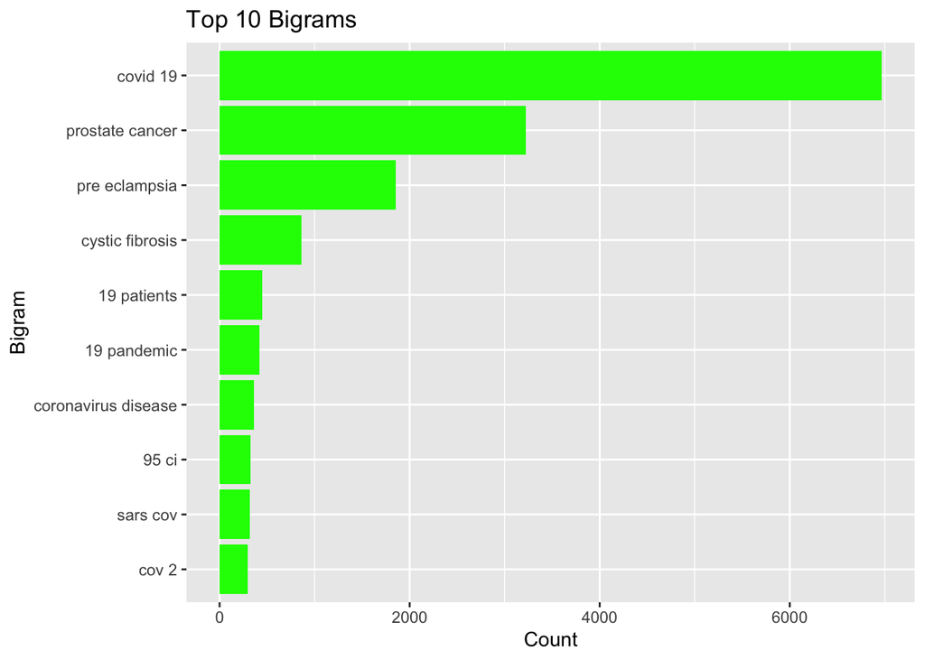

```r
ggplot(top10_bigrams, aes(x = reorder(bigram, n), y = n)) +
  geom_col(fill="green") +
  coord_flip() +
  labs(title = "Top 10 Bigrams",
       x = "Bigram",
       y = "Count")
```

I decided to remove stop words to get some better insights into the data. Interestingly, “covid 19” is far and away the most common bigram in these abstracts.

### Question 4

```r
tfidf <- tokens_clean %>%
  dplyr::count(term, word, sort = TRUE) %>%
  bind_tf_idf(word, term, n)
top_tfidf <- tfidf %>%
  group_by(term) %>%
  slice_max(tf_idf, n = 5)

top_tfidf
```

```
# A tibble: 25 × 6
# Groups:   term [5]
   term            word            n      tf   idf  tf_idf
   <chr>           <chr>       <int>   <dbl> <dbl>   <dbl>
 1 covid           covid        7275 0.0647  1.61  0.104
 2 covid           pandemic      800 0.00711 1.61  0.0114
 3 covid           coronavirus   647 0.00575 1.61  0.00926
 4 covid           sars          372 0.00331 1.61  0.00532
 5 covid           cov           334 0.00297 1.61  0.00478
 6 cystic fibrosis cf            625 0.0234  0.916 0.0215
 7 cystic fibrosis fibrosis      867 0.0325  0.511 0.0166
 8 cystic fibrosis cystic        862 0.0323  0.511 0.0165
 9 cystic fibrosis cftr           86 0.00322 1.61  0.00518
10 cystic fibrosis sweat          83 0.00311 1.61  0.00500
# ℹ 15 more rows
```

- The 5 highest TF-IDF scores for “covid” are (covid, pandemic, coronavirus, sars, cov)
- The 5 highest TF-IDF scores for “cystic fibrosis” are (cf, fibrosis, cystic, cftr, sweat)
- The 5 highest TF-IDF scores for “meningitis” are (meningitis, meningeal, pachymeningitis, csf, meninges)
- The 5 highest TF-IDF scores for “preeclampsia” are (eclampsia, preeclampsia, pregnancy, maternal, gestational)
- The 5 highest TF-IDF scores for “prostate cancer” are (prostate, androgen, psa, prostatectomy, castration)  
  We notice some slight differences from our Question 2 results (since this was the one that removed the stop words). Particularly for prostate cancer, we see some big changes: the TF-IDF analysis shows more specific and descriptive words rather than words that broadly describe prostate cancer. I also thought it was interesting that “sweat” appeared for cystic fibrosis; I’m not sure why that would be included in the top 5 results but it would be interesting to look into. Generally, we get more specific and not see these very broad terms as we look at the TF-IDF analysis compared to the initial analysis.

## Sentiment Analysis

### Question 5

```r
library(textdata)
nrc <- tidytext::get_sentiments("nrc")
tokens_nrc <- tokens %>%
  inner_join(nrc, by = c("word" = "word"))
sentiment_counts <- tokens_nrc %>%
  count(term, sentiment, sort = TRUE)
top_sentiment <- sentiment_counts %>%
  group_by(term) %>%
  slice_max(n, n = 1)

top_sentiment
```

```
# A tibble: 5 × 3
# Groups:   term [5]
  term            sentiment     n
  <chr>           <chr>     <int>
1 covid           positive   9874
2 cystic fibrosis positive   2747
3 meningitis      negative   2109
4 preeclampsia    positive   8014
5 prostate cancer negative   8918
```

We see that the search terms “covid”, “cystic fibrosis”, and “preeclampsia” are associated with positive sentiment while “meningitis” and “prostate cancer” are associated with negative sentiment. This is kind of surprising to me that any of these diseases could be associated with positive sentiment, unless it’s in regard to some kind of treatment.

```r
tokens_nrc_filtered <- tokens_nrc %>%
  filter(!sentiment %in% c("positive", "negative"))

sentiment_counts_filtered <- tokens_nrc_filtered %>%
  count(term, sentiment, sort = TRUE)

top_sentiment_filtered <- sentiment_counts_filtered %>%
  group_by(term) %>%
  slice_max(n, n = 1)

top_sentiment_filtered
```

```
# A tibble: 5 × 3
# Groups:   term [5]
  term            sentiment        n
  <chr>           <chr>        <int>
1 covid           fear          7730
2 cystic fibrosis disgust       1714
3 meningitis      fear          1510
4 preeclampsia    anticipation  4780
5 prostate cancer fear          8118
```

When we remove “positive” and “negative” sentiments, we get results that are more in line with my expectations. COVID, meningitis, and prostate cancer are associated with fear, which makes sense, and disgust and anticipation are understandable sentiments for these diseases.

### Question 6

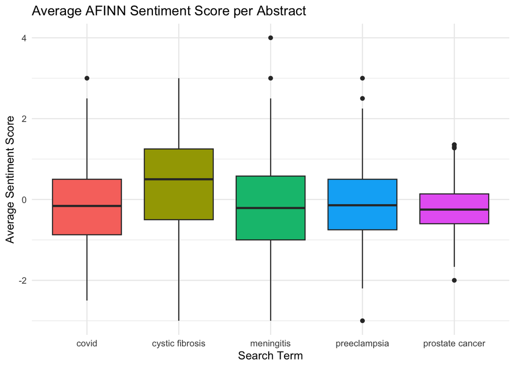

```r
pubmed_indexed <- pubmed %>%
  mutate(abstract_id = row_number())

tokens_afinn <- pubmed_indexed %>%
  unnest_tokens(word, abstract)

afinn <- tidytext::get_sentiments("afinn")

tokens_afinn <- tokens_afinn %>%
  inner_join(afinn, by = "word")

abstract_sentiment <- tokens_afinn %>%
  group_by(abstract_id, term) %>%
  summarize(avg_score = mean(value), .groups = "drop")

ggplot(abstract_sentiment, aes(x = term, y = avg_score, fill = term)) +
  geom_boxplot() +
  labs(
    title = "Average AFINN Sentiment Score per Abstract",
    x = "Search Term",
    y = "Average Sentiment Score"
  ) +
  theme_minimal() +
  theme(legend.position = "none")
```

Examining the boxplots, we see that cystic fibrosis generally has more positive sentiment than the other diseases. Other than that, the diseases are pretty similar in regards to sentiment, but prostate cancer does seem to have the most negative sentiment, which makes sense given its severity.